# Reproducible Research - Peer Assessment 1

## Imputing missing values

```r
numMissingValues <- length(which(is.na(activityData$steps)))
```

##### 3. Create a new dataset that is equal to the original dataset but with the missing data filled in.

```r
activityDataFilled <- activityData
activityDataFilled$steps <- impute(activityData$steps, fun=mean)
```

##### 4. Make a histogram of the total number of steps taken each day

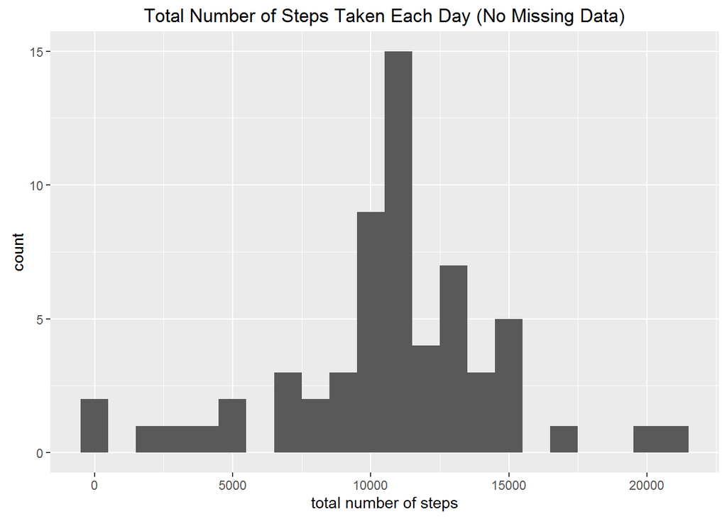

```r
totalStepsFilled <- tapply(activityDataFilled$steps, activityDataFilled$date, sum)
qplot(totalStepsFilled, main = "Total Number of Steps Taken Each Day (No Missing Data)", xlab='total number of steps', binwidth=1000)
```

```r
totalStepsFilledMean <- mean(totalStepsFilled )
totalStepsFilledMedian <- median(totalStepsFilled )
```

## Are there differences in activity patterns between weekdays and weekends?

##### 1. Create a new factor variable in the dataset with two levels – “weekday” and “weekend” indicating whether a given date is a weekday or weekend day.

```r
dayType <- function(date) {
    day <- weekdays(date)
    if (day %in% c("lunedì", "martedì", "mercoledì", "giovedì", "venerdì"))
        return("weekday")
    else if (day %in% c("sabato", "domenica"))
        return("weekend")
    else
        stop("invalid date")
}

activityDataFilled$date <- as.Date(activityDataFilled$date)
activityDataFilled$day <- sapply(activityDataFilled$date, FUN=dayType)
```

##### 2. Make a panel plot containing a time series plot

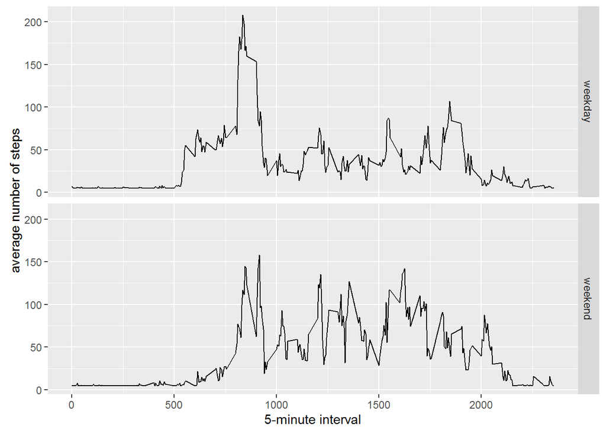

```r
avgActivityDataFilled <- aggregate(steps ~ interval + day, data=activityDataFilled, mean)
ggplot(avgActivityDataFilled, aes(interval, steps)) + geom_line() + facet_grid(day ~ .) +
    xlab("5-minute interval") + ylab("average number of steps")
```